# Exercise - Proteolytic cleavage; Beta-Lactoglobulin

Marc A.T. Teunis

2024-01-11

```r
knitr::opts_chunk$set(echo = TRUE,
                      warning = FALSE,
                      message = FALSE,
                      error = FALSE,
                      results = 'show',
                      fig.show = 'show')
```

# Introduction

We use the protein Beta-lactoglobulin as an example to show an *in-slico* chemical analysis workflow in R/Bioconductor.

Here we will perform an enzymatic digestion on the native beta-lactoglobulin (`BLG`) protein of different species. We will use the Cow, Goat and the Sheep sequence to explore the theory behind mass-spectrometery. The amino acid sequence for the Beta-lac (`BLG`) gene for different organisms (Cow, Sheep & Goat) will be used.

We also practice a little with alignment in this exercise.

The name (`external_gene_name`) of the beta-lac encoding gene is `BLG`. Synonyms are: `PAEP`, `LGB` or `Beta-LG`

# Packages

Load the following packages in your session:

```r
library(biomaRt)
library(seqinr)
library(rentrez)
library(GEOquery)
library(Biostrings)
library(DECIPHER)
library(cleaver)
library(OrgMassSpecR)
library(protr)
library(tidyverse)
library(here)
```

# Data

Obtain the amino-acid sequences for the Beta-Lactoglobuline protein (`BLG`) from Goat (*C. hircus*), Sheep (*O. aries*) and Domestic Cow (*B. taurus*). See code chunks below.

## Retrieve amino acid sequence of `BLG` protein for Goat

Because the Goat sequence is not available via a Biomart search we download this sequence directly from Uniprot.

The following chunk downloads the amino acid sequence for the `BLG` protein from here:  
https://www.uniprot.org/uniprot/P02756.fasta And put the downloaded `.fasta` file in the `./data` folder.

```r
## download Goat aa sequence
## dir.create(here("data"))
url <- c("https://www.uniprot.org/uniprot/P02756.fasta")
download.file(url = url, destfile = here("data", "chircus_blg_aminoacids.fasta"))
```

## Convert to Amino Acids

```r
chircus_blg_aa <- Biostrings::readAAStringSet(filepath = here("data", "chircus_blg_aminoacids.fasta"))
names(chircus_blg_aa) <- c("chircus")
chircus_blg_aa
```

```
## AAStringSet object of length 1:
##     width seq                                               names
## [1]   180 MKCLLLALGLALACGIQAIIVTQ...LKALPMHIRLAFNPTQLEGQCHV chircus
```

Alternatively, you can also use the `{protr}` package to download sequences directly from UniProt:

```r
protr::getUniProt("P02756") %>%
  unlist %>%
  AAStringSet()
```

```
## AAStringSet object of length 1:
##     width seq
## [1]   180 MKCLLLALGLALACGIQAIIVTQTMKGLDIQKVA...KEALEKFDKALKALPMHIRLAFNPTQLEGQCHV
```

## Retrieve aa sequence of `BLG` protein for the Cow (`_B. taurus_`).

The BLG protein has multiple synonyms. The code below uses an `lapply` loop to test for each known synonym: `BLG`, `PAEP` `Beta-LG` and `LGB`

```r
## specify the 'market place' to use
mart <- useMart(biomart = "ensembl")
## specify from which 'dataset', in this case from Domestic Cow
btaurus_mart <- useDataset(
  dataset = "btaurus_gene_ensembl",
  mart = mart)

## there are several names for the same protein
beta_lac_gene_name <- c("BLG", "PAEP", "LGB", "Beta-LG")

attributes <- listAttributes(mart = btaurus_mart)

loop_gene_names <- function(x, mart){
  results <- getBM(
    attributes = c("ensembl_gene_id",        ## attributes are output
                   "external_gene_name",
                    "coding"),
    filters = "external_gene_name",          ## filters in input type
    values = x,
    mart = mart) %>%
    as_tibble()
    # print()
  return(results)
}

## "PAEP" yields a result, using that
query <- lapply(as.list(beta_lac_gene_name),
                loop_gene_names,
                mart = btaurus_mart)
query
```

```
## [[1]]
## # A tibble: 0 × 3
## # ℹ 3 variables: external_gene_name <lgl>, coding <lgl>, ensembl_gene_id <lgl>
##
## [[2]]
## # A tibble: 3 × 3
##   external_gene_name coding                                      ensembl_gene_id
##   <chr>              <chr>                                       <chr>
## 1 PAEP               ATGAAGTGCCTCCTGCTTGCCCTGGCCCTCACTTGTGGCGCC… ENSBTAG0000001…
## 2 PAEP               ATGAAGTGCCTCCTGCTTGCCCTGGCCCTCACTTGTGGCGCC… ENSBTAG0000001…
## 3 PAEP               ATGAAGTGCCTCCTGCTTGCCCTGGCCCTCACTTGTGGCGCC… ENSBTAG0000001…
##
## [[3]]
## # A tibble: 0 × 3
## # ℹ 3 variables: external_gene_name <lgl>, coding <lgl>, ensembl_gene_id <lgl>
##
## [[4]]
## # A tibble: 0 × 3
## # ℹ 3 variables: external_gene_name <lgl>, coding <lgl>, ensembl_gene_id <lgl>
```

```r
names(query) <- beta_lac_gene_name

## isolating the result in a dataframe
query_btaurus <- query[["PAEP"]]

btaurus_blg_aa <- DNAStringSet(query_btaurus$coding) %>% Biostrings::translate()
btaurus_blg_aa@ranges@NAMES <- c("btaurus", "btaurus", "btaurus")
btaurus_blg_aa
```

```
## AAStringSet object of length 3:
##     width seq                                               names
## [1]   246 MKCLLLALALTCGAQALIVTQTM...RSEPEGQVVQSRRPNFKTSKAL* btaurus
## [2]   179 MKCLLLALALTCGAQALIVTQTM...KALPMHIRLSFNPTQLEEQCHI* btaurus
## [3]   237 MKCLLLALALTCGAQALIVTQTM...LGPPAWGRSSFSNKGINLCSPF* btaurus
```

## Retrieve aa sequence for Sheep

Now do the same for the Sheep `BLG` protein sequence. Use the code example above.

```r
mart <- useMart(biomart = "ensembl")
oaries_mart <- useDataset(dataset = "oaries_gene_ensembl",
                        mart=mart)

#datasets <- listDatasets(mart) %>% as_tibble()
attributes <- listAttributes(mart = oaries_mart)
#filters <- listFilters(chircus_mart)

## using loop again
query_sheep <- lapply(as.list(beta_lac_gene_name), loop_gene_names, mart = oaries_mart)
query_sheep
```

```
## [[1]]
## # A tibble: 0 × 3
## # ℹ 3 variables: external_gene_name <lgl>, coding <lgl>, ensembl_gene_id <lgl>
##
## [[2]]
## # A tibble: 1 × 3
##   external_gene_name coding                                      ensembl_gene_id
##   <chr>              <chr>                                       <chr>
## 1 PAEP               CAAGCCTGCTGTCTCAGCCCTCCACTCCCTGCAGAGCTCAGA… ENSOARG0000000…
##
## [[3]]
## # A tibble: 0 × 3
## # ℹ 3 variables: external_gene_name <lgl>, coding <lgl>, ensembl_gene_id <lgl>
##
## [[4]]
## # A tibble: 0 × 3
## # ℹ 3 variables: external_gene_name <lgl>, coding <lgl>, ensembl_gene_id <lgl>
```

```r
names(query_sheep) <- beta_lac_gene_name
query_sheep <- query_sheep[["PAEP"]]
query_sheep
```

```
## # A tibble: 1 × 3
##   external_gene_name coding                                      ensembl_gene_id
##   <chr>              <chr>                                       <chr>
## 1 PAEP               CAAGCCTGCTGTCTCAGCCCTCCACTCCCTGCAGAGCTCAGA… ENSOARG0000000…
```

```r
oaries_blg_aa <- DNAStringSet(query_sheep$coding) %>% Biostrings::translate()
names(oaries_blg_aa) <- "oaries"
oaries_blg_aa
```

```
## AAStringSet object of length 1:
##     width seq                                               names
## [1]   175 QACCLSPPLPAELRSTTPAAETM...DKALKALPPAPQASQEEGQCHV* oaries
```

Combine the three seperate amino acid sequences encoding the `BLG` protein from Cow, Goat and Sheet to one `AAStringSet`. Provide appropriate names for each sequence by setting names using `names(...) <- c(...)`.

How long is each protein(fragment)?

```r
all_aa_trim <- c(btaurus_blg_aa,
                 oaries_blg_aa,
                 chircus_blg_aa)
all_aa_trim
```

```
## AAStringSet object of length 5:
##     width seq                                               names
## [1]   246 MKCLLLALALTCGAQALIVTQTM...RSEPEGQVVQSRRPNFKTSKAL* btaurus
## [2]   179 MKCLLLALALTCGAQALIVTQTM...KALPMHIRLSFNPTQLEEQCHI* btaurus
## [3]   237 MKCLLLALALTCGAQALIVTQTM...LGPPAWGRSSFSNKGINLCSPF* btaurus
## [4]   175 QACCLSPPLPAELRSTTPAAETM...DKALKALPPAPQASQEEGQCHV* oaries
## [5]   180 MKCLLLALGLALACGIQAIIVTQ...LKALPMHIRLAFNPTQLEGQCHV chircus
```

## Exercise signal peptide trim and compare to Robert Jan

```r
all_aa_trim_trim <- AAStringSet(all_aa_trim, start = 17)
all_aa_trim_trim
```

```
## AAStringSet object of length 5:
##     width seq                                               names
## [1]   230 LIVTQTMKGLDIQKVAGTWYSLA...RSEPEGQVVQSRRPNFKTSKAL* btaurus
## [2]   163 LIVTQTMKGLDIQKVAGTWYSLA...KALPMHIRLSFNPTQLEEQCHI* btaurus
## [3]   221 LIVTQTMKGLDIQKVAGTWYSLA...LGPPAWGRSSFSNKGINLCSPF* btaurus
## [4]   159 TPAAETMKGLDIQKVAGTWHSLA...DKALKALPPAPQASQEEGQCHV* oaries
## [5]   164 QAIIVTQTMKGLDIQKVAGTWYS...LKALPMHIRLAFNPTQLEGQCHV chircus
```

```r
rjve_seq <- "LIVTQTMKGLDIQKVAGTWYSLAMAASDISLLDAQSAPLRVYVEELKPTPEGDLEILLQKWENDECAQKKIIAEKTKIPAVFKIDALNENKVLVLDTDYKKYLLVCMENSAEPEQSLVCQCLVRTPEVDDEALEKFDKALKALPMHIRLSFNPTQLEEQCHI"

rjve_seq <- AAStringSet(rjve_seq)
rjve_seq@ranges@NAMES <- "RJVE_seq"

new_sequences <- c(rjve_seq, all_aa_trim_trim)

alignment_blg <- AlignSeqs(new_sequences[1:3])
```

[output not shown]

```r
BrowseSeqs(alignment_blg)

alignment_blg
```

```
## AAStringSet object of length 3:
##     width seq                                               names
## [1]   230 LIVTQTMKGLDIQKVAGTWYSLA...-----------------EQCHI- RJVE_seq
## [2]   230 LIVTQTMKGLDIQKVAGTWYSLA...RSEPEGQVVQSRRPNFKTSKAL* btaurus
## [3]   230 LIVTQTMKGLDIQKVAGTWYSLA...-----------------EQCHI* btaurus
```

# Multiple sequence alignment

**2A** Align the amino acid sequences for the `BLG` protein from Cow, Sheep and Goat. What can you conclude from this alignment?

```r
alignment_blg <- AlignSeqs(all_aa_trim_trim)
```

[output not shown]

```r
BrowseSeqs(alignment_blg)
```

Align the sequences for `BLG` protein from Cow and Sheep, what is you conclusion about the homology

```r
alignment_blg <- AlignSeqs(all_aa_trim_trim[c(1:4)])
```

[output not shown]

```r
BrowseSeqs(alignment_blg)
```

Now do the same for the sequence from Cow and Goat Which animal is most related to the Cow, on the basis of this alignment? Can you think of a way to illustrate this further?

```r
alignment_blg <- AlignSeqs(all_aa_trim[c(1, 5)])
```

[output not shown]

```r
BrowseSeqs(alignment_blg)
```

## Simularity scores

Calculate the percentage simularity on the basis of the primary amino acid sequence between the `BLG` proteins. Use the *Bos taurus* sequence as a reference sequence (`pattern`).

**TIPS**

- use the `biostrings::pairwiseAlignment()` function
- use the `biostrings::pid()` function to get the simularity score, use the setting in this function `type = 'PID1'`. Look at the help file of this function to see what this setting does.

```r
all_aa_trim
```

```
## AAStringSet object of length 5:
##     width seq                                               names
## [1]   246 MKCLLLALALTCGAQALIVTQTM...RSEPEGQVVQSRRPNFKTSKAL* btaurus
## [2]   179 MKCLLLALALTCGAQALIVTQTM...KALPMHIRLSFNPTQLEEQCHI* btaurus
## [3]   237 MKCLLLALALTCGAQALIVTQTM...LGPPAWGRSSFSNKGINLCSPF* btaurus
## [4]   175 QACCLSPPLPAELRSTTPAAETM...DKALKALPPAPQASQEEGQCHV* oaries
## [5]   180 MKCLLLALGLALACGIQAIIVTQ...LKALPMHIRLAFNPTQLEGQCHV chircus
```

```r
btaurus_vs_oaries <- pairwiseAlignment(
  pattern = all_aa_trim[1],
  subject = all_aa_trim[2]
  )
btaurus_vs_chircus <- pairwiseAlignment(
  pattern = all_aa_trim[1],
  subject = all_aa_trim[3]
  )
oaries_vs_chircus <- pairwiseAlignment(
  pattern = all_aa_trim[2], subject = all_aa_trim[3]
  )

?pid

pid_string <- "PID1"

# percentage simularity for muliple alignments
pid(btaurus_vs_oaries, type = pid_string)
```

```
## [1] 71.54472
```

```r
pid(btaurus_vs_chircus, type = pid_string)
```

```
## [1] 76.4
```

```r
pid(oaries_vs_chircus, type = pid_string)
```

```
## [1] 75.10549
```

# Proteolytic digestion

Review the vignette from the `{OrgMassSpecR}` package. Try predicting the fragments by proteolytic digestion with the trypsin enzyme, for the *Bos taurus* BLG protein.

**TIPS:**

- Look at the vignette for the `{OrgMassSpecR}` package, it has some really good examples.
- set the `enzyme` option to `trypsin`
- Review the code below from the presentation “Mass Spectometry”: recycle the code to find the solution for 3A

```r
browseVignettes(package = "OrgMassSpecR")

seq <- all_aa_trim %>%
  as.list()

## remove * from sequences
#seq <- map(seq, str_remove_all, pattern = "\\*")
seq <- modified_aa_list <- lapply(seq, function(x) gsub("\\*$", "", x))

btaurus_blg_trypsin <- OrgMassSpecR::Digest(
  sequence = seq[[1]], enzyme ="trypsin"
  ) %>%
  as_tibble() %>%
  mutate(width = nchar(peptide)) %>%
  arrange(width) %>%
  print()
```

```
## # A tibble: 30 × 8
##    peptide start  stop    mc   mz1   mz2   mz3 width
##    <chr>   <dbl> <int> <dbl> <dbl> <dbl> <dbl> <int>
##  1 K          86    86     0  147.  74.1  49.7     1
##  2 K         117   117     0  147.  74.1  49.7     1
##  3 R         198   198     0  175.  88.1  59.0     1
##  4 MK          1     2     0  278. 140.   93.4     2
##  5 TK         92    93     0  248. 125.   83.4     2
##  6 TR        186   187     0  276. 139.   92.7     2
##  7 SR        188   189     0  262. 132.   88.1     2
##  8 AR        202   203     0  246. 124.   82.7     2
##  9 AL        244   245     0  203. 102.   68.4     2
## 10 FDK       152   154     0  409. 205.  137.      3
## # ℹ 20 more rows
```

## Write a function that takes a sequence and returns a nice table

```r
## a single sequence as input:
digest_sequence <- function(peptide, enzyme){

  digestion <- OrgMassSpecR::Digest(peptide, enzyme = enzyme) %>%
     as_tibble() %>%
     mutate(width = nchar(peptide)) %>%
     arrange(width)

  return(digestion)

}

digest_sequence(seq[[1]], enzyme = "trypsin")
```

```
## # A tibble: 30 × 8
##    peptide start  stop    mc   mz1   mz2   mz3 width
##    <chr>   <dbl> <int> <dbl> <dbl> <dbl> <dbl> <int>
##  1 K          86    86     0  147.  74.1  49.7     1
##  2 K         117   117     0  147.  74.1  49.7     1
##  3 R         198   198     0  175.  88.1  59.0     1
##  4 MK          1     2     0  278. 140.   93.4     2
##  5 TK         92    93     0  248. 125.   83.4     2
##  6 TR        186   187     0  276. 139.   92.7     2
##  7 SR        188   189     0  262. 132.   88.1     2
##  8 AR        202   203     0  246. 124.   82.7     2
##  9 AL        244   245     0  203. 102.   68.4     2
## 10 FDK       152   154     0  409. 205.  137.      3
## # ℹ 20 more rows
```

```r
## loop over each sequence
all_predictions <- map(seq, digest_sequence, enzyme = "trypsin")

all_predictions[[1]]
```

```
## # A tibble: 30 × 8
##    peptide start  stop    mc   mz1   mz2   mz3 width
##    <chr>   <dbl> <int> <dbl> <dbl> <dbl> <dbl> <int>
##  1 K          86    86     0  147.  74.1  49.7     1
##  2 K         117   117     0  147.  74.1  49.7     1
##  3 R         198   198     0  175.  88.1  59.0     1
##  4 MK          1     2     0  278. 140.   93.4     2
##  5 TK         92    93     0  248. 125.   83.4     2
##  6 TR        186   187     0  276. 139.   92.7     2
##  7 SR        188   189     0  262. 132.   88.1     2
##  8 AR        202   203     0  246. 124.   82.7     2
##  9 AL        244   245     0  203. 102.   68.4     2
## 10 FDK       152   154     0  409. 205.  137.      3
## # ℹ 20 more rows
```

```r
all_predictions[[2]]
```

```
## # A tibble: 19 × 8
##    peptide                    start  stop    mc   mz1    mz2   mz3 width
##    <chr>                      <dbl> <int> <dbl> <dbl>  <dbl> <dbl> <int>
##  1 K                             86    86     0  147.   74.1  49.7     1
##  2 K                            117   117     0  147.   74.1  49.7     1
##  3 MK                             1     2     0  278.  140.   93.4     2
##  4 TK                            92    93     0  248.  125.   83.4     2
##  5 FDK                          152   154     0  409.  205.  137.      3
##  6 ALK                          155   157     0  331.  166.  111.      3
##  7 IIAEK                         87    91     0  573.  287.  192.      5
##  8 GLDIQK                        25    30     0  673.  337.  225.      6
##  9 IPAVFK                        94    99     0  674.  338.  225.      6
## 10 ALPMHIR                      158   164     0  837.  419.  280.      7
## 11 IDALNENK                     100   107     0  916.  459.  306.      8
## 12 WENGECAQK                     77    85     0 1121.  561.  374.      9
## 13 VLVLDTDYK                    108   116     0 1066.  533.  356.      9
## 14 TPEVDDEALEK                  141   151     0 1246.  623.  416.     11
## 15 LSFNPTQLEEQCHI               165   178     0 1716.  858.  573.     14
## 16 VYVEELKPTPEGDLEILLQK          57    76     0 2313. 1157.  772.     20
## 17 CLLLALALTCGAQALIVTQTMK         3    24     0 2389. 1195.  797.     22
## 18 YLLFCMENSAEPEQSLACQCLVR      118   140     0 2818. 1410.  940.     23
## 19 VAGTWYSLAMAASDISLLDAQSAPLR    31    56     0 2707. 1354.  903.     26
```

```r
all_predictions[[3]]
```

```
## # A tibble: 27 × 8
##    peptide start  stop    mc   mz1   mz2   mz3 width
##    <chr>   <dbl> <int> <dbl> <dbl> <dbl> <dbl> <int>
##  1 K          86    86     0  147.  74.1  49.7     1
##  2 K         117   117     0  147.  74.1  49.7     1
##  3 R         185   185     0  175.  88.1  59.0     1
##  4 R         197   197     0  175.  88.1  59.0     1
##  5 MK          1     2     0  278. 140.   93.4     2
##  6 TK         92    93     0  248. 125.   83.4     2
##  7 NR        198   199     0  289. 145.   97.1     2
##  8 FDK       152   154     0  409. 205.  137.      3
##  9 ALK       155   157     0  331. 166.  111.      3
## 10 CHPR      186   189     0  569. 285.  190.      4
## # ℹ 17 more rows
```

## Let’s examine the Cow a bit further - We only examine the first sequence of the AAStringSet

```r
## store as xlsx
readr::write_csv(
  btaurus_blg_trypsin,
  file = here::here("data",
                   "btaurus_blg_trypsin.csv"))

## get the cleavage ranges
ranges <- cleavageRanges(all_aa_trim$btaurus, enzym = "trypsin")

tibble(width = ranges@width,
       start = ranges@start) %>%
  arrange(width)
```

```
## # A tibble: 30 × 2
##    width start
##    <int> <int>
##  1     1    86
##  2     1   117
##  3     1   198
##  4     2     1
##  5     2    92
##  6     2   186
##  7     2   188
##  8     2   202
##  9     3   152
## 10     3   155
## # ℹ 20 more rows
```

```r
## get only cleavage sites
sites <- cleavageSites(all_aa_trim[1], enzym = "trypsin")
sites
```

```
## $btaurus
##  [1]   2  24  30  56  76  85  86  91  93  99 107 116 117 140 151 154 157 164 185
## [20] 187 189 197 198 201 203 224 235 240 243
```

**3B** Recycling the code from question 3A, try predicting the peptide-fragments from the Goat and the Sheep. Combine these in a IRanges object, with appropriate names (use for example Species and width). Use `lapply` to achieve your goal.

# Mass spectrometric analysis

## Get all structure formulas for each peptide in all digestions

```r
formula <- OrgMassSpecR::ConvertPeptide(
  btaurus_blg_trypsin$peptide[1])

formula
```

```
## $C
## [1] 6
##
## $H
## [1] 14
##
## $N
## [1] 2
##
## $O
## [1] 2
##
## $S
## [1] 0
```

```r
MonoisotopicMass(formula = ConvertPeptide(btaurus_blg_trypsin$peptide[1]))
```

```
## [1] 146.1055
```

```r
MolecularWeight(formula = ConvertPeptide(btaurus_blg_trypsin$peptide[1]))
```

```
## [1] 146.188
```

```r
MonoisotopicMass(formula = ConvertPeptide(btaurus_blg_trypsin$peptide[19]))
```

```
## [1] 915.4662
```

```r
MolecularWeight(formula = ConvertPeptide(btaurus_blg_trypsin$peptide[19]))
```

```
## [1] 915.987
```

```r
## Compare to results of Robert Jan on slide 21

as_tibble(formula)
```

```
## # A tibble: 1 × 5
##       C     H     N     O     S
##   <dbl> <dbl> <dbl> <dbl> <dbl>
## 1     6    14     2     2     0
```

```r
# btaurus_blg_trypsin$fragment

get_formula <- function(peptide){

  formula <- OrgMassSpecR::ConvertPeptide(peptide)
  df <- formula %>% as_tibble()

    return(df)

}

get_formula(peptide = btaurus_blg_trypsin$peptide[1])
```

```
## # A tibble: 1 × 5
##       C     H     N     O     S
##   <dbl> <dbl> <dbl> <dbl> <dbl>
## 1     6    14     2     2     0
```

```r
peptide_list <- as.list(btaurus_blg_trypsin$peptide)

## safe loop with error catching
formulae <- map(peptide_list, safely(get_formula))
formulae <- purrr::transpose(formulae)
formulae$result %>% dplyr::bind_rows()
```

```
## # A tibble: 30 × 5
##        C     H     N     O     S
##    <dbl> <dbl> <dbl> <dbl> <dbl>
##  1     6    14     2     2     0
##  2     6    14     2     2     0
##  3     6    14     4     2     0
##  4    11    23     3     3     1
##  5    10    21     3     4     0
##  6    10    21     5     4     0
##  7     9    19     5     4     0
##  8     9    19     5     3     0
##  9     9    18     2     3     0
## 10    19    28     4     6     0
## # ℹ 20 more rows
```

```r
formulae$error
```

## Get all Monoisotopic masses

```r
get_monoisotopic_mass <- function(peptide){

  formula <- OrgMassSpecR::MonoisotopicMass(
    ConvertPeptide(peptide))
  df <- formula %>% as_tibble()
  df$peptide <- peptide
    return(df)

}

get_monoisotopic_mass(peptide = btaurus_blg_trypsin$peptide[1])
```

```
## # A tibble: 1 × 2
##   value peptide
##   <dbl> <chr>
## 1  146. K
```

```r
map(peptide_list, get_monoisotopic_mass) %>%
  dplyr::bind_rows() %>%
  rename(monoisotopic_mass = value)
```

```
## # A tibble: 30 × 2
##    monoisotopic_mass peptide
##                <dbl> <chr>
##  1              146. K
##  2              146. K
##  3              174. R
##  4              277. MK
##  5              247. TK
##  6              275. TR
##  7              261. SR
##  8              245. AR
##  9              202. AL
## 10              408. FDK
## # ℹ 20 more rows
```

## Isotopic Distribution

```r
id <- IsotopicDistribution(formula = formula) %>%
  as_tibble() %>%
  print()
```

```
## # A tibble: 4 × 3
##      mz intensity percent
##   <dbl>     <int>   <dbl>
## 1  146.      9243  100
## 2  147.       708    7.66
## 3  148.        46    0.5
## 4  149.         3    0.03
```

## Plot Isotopic Distribution MZ - Intensity

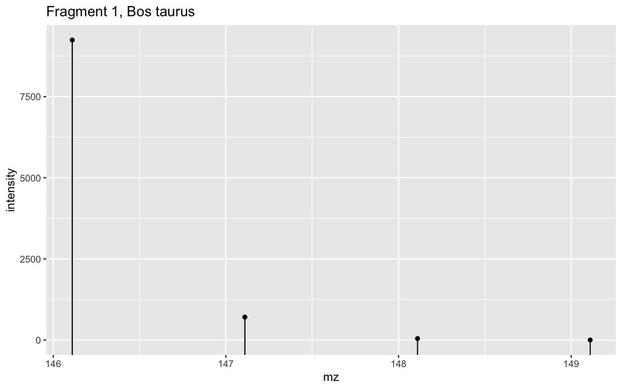

```r
ggplot(data = id, aes(x = mz, y = intensity)) +
  geom_point() +
  geom_segment(aes(xend = mz, yend=-Inf)) +
  ggtitle("Fragment 1, Bos taurus")
```

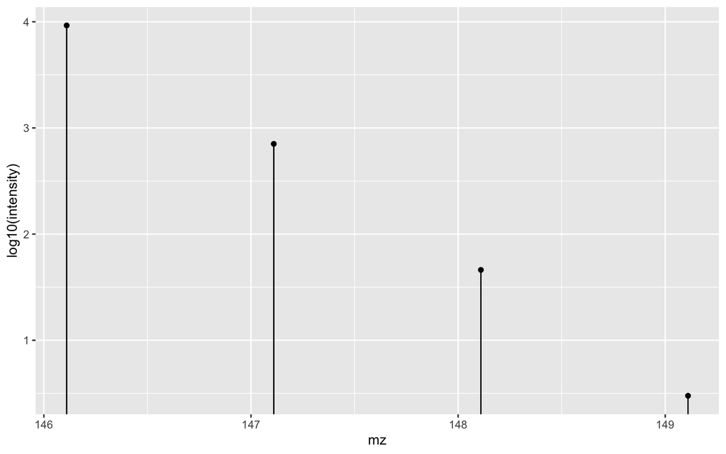

```r
ggplot(data = id, aes(x = mz, y = log10(intensity))) +
  geom_point() +
  geom_segment(aes(xend = mz, yend=-Inf))
```

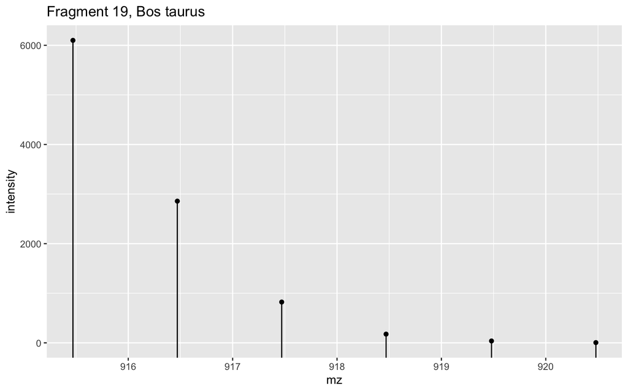

```r
IsotopicDistribution(formula = get_formula(peptide = btaurus_blg_trypsin$peptide[19])) %>%
  as_tibble() %>%
    ggplot(aes(x = mz, y = intensity)) +
      geom_point() +
      geom_segment(aes(xend = mz, yend=-Inf)) +
      ggtitle("Fragment 19, Bos taurus")
```

## Identification

```r
### Next step is identification
```